# Nota: ¿qué pasa si el IGAE tiene más error que el PIB?

```r
library(lavaan)     # SEM
library(semTools)   # confiabilidad con SEM
library(nlme)       # modelos multinivel con varianzas de error distintas
knitr::opts_chunk$set(message = FALSE, warning = FALSE)
```

# 1. El planteamiento

En la práctica anterior supusimos que el IGAE y el PIB tienen errores **del mismo tamaño** (mediciones paralelas). Es razonable pensar que no es así: el PIB trimestral usa información más completa que el IGAE, así que probablemente tiene menos error.

En esta nota los errores siguen siendo aleatorios e independientes, pero de distinto tamaño:

- IGAE: varianza del error = 4 (más error).
- PIB: varianza del error = 1 (menos error).
- Crecimiento verdadero: varianza = 6.25.

Con estos valores, la confiabilidad de cada indicador es distinta:

- IGAE: 6.25 / (6.25 + 4) = .61
- PIB: 6.25 / (6.25 + 1) = .86

```r
d <- read.csv("igae_pib_desigual.csv")
head(d)
```

```
##   trimestre verdadero  igae  pib desempleo
## 1    2001T1      0.43 -0.81 0.84      0.74
## 2    2001T2      2.46  2.54 4.15     -0.45
## 3    2001T3     -0.09 -1.91 1.50      1.22
## 4    2001T4      5.99  6.30 5.66     -1.31
## 5    2002T1      2.82  1.51 0.54      0.25
## 6    2002T2     -0.05  3.48 2.45      1.07
```

Como los datos son simulados, conocemos el crecimiento verdadero y podemos ver el error de cada indicador directamente:

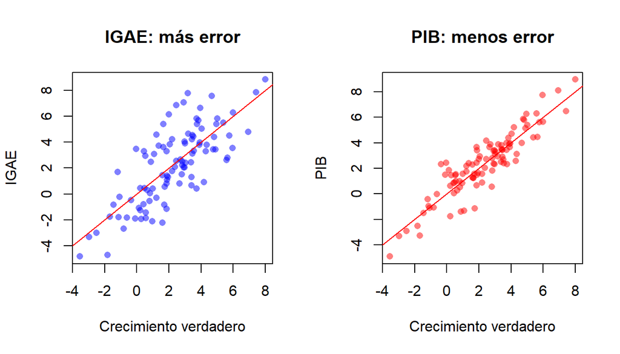

```r
par(mfrow = c(1, 2))
plot(d$verdadero, d$igae, pch = 16, col = rgb(0, 0, 1, .5),
     xlab = "Crecimiento verdadero", ylab = "IGAE", main = "IGAE: más error")
abline(0, 1, col = "red")
plot(d$verdadero, d$pib, pch = 16, col = rgb(1, 0, 0, .5),
     xlab = "Crecimiento verdadero", ylab = "PIB", main = "PIB: menos error")
abline(0, 1, col = "red")
```

```r
par(mfrow = c(1, 1))
```

Los puntos del IGAE se alejan más de la diagonal.

# 2. Si seguimos suponiendo errores iguales

El modelo de la práctica anterior (paralelo) estima **una sola** varianza de error para ambos indicadores:

```r
mod_par <- '
  A =~ 1*igae + 1*pib
  igae ~~ e*igae          # misma varianza de error
  pib  ~~ e*pib
  igae ~ m*1
  pib  ~ m*1
'
fit_par <- sem(mod_par, data = d)
subset(parameterEstimates(fit_par), op == "~~")[, c("lhs", "rhs", "est")]
```

```
##    lhs  rhs   est
## 3 igae igae 2.448
## 4  pib  pib 2.448
## 7    A    A 4.931
```

La varianza de error estimada queda **entre** la del IGAE y la del PIB: es un promedio de ambas. El modelo le asigna la misma confiabilidad a los dos indicadores, lo que subestima la calidad del PIB y sobreestima la del IGAE.

# 3. Permitir errores distintos

Liberamos las varianzas de error (quitamos la etiqueta común `e`). Las cargas siguen en 1 y los interceptos siguen iguales: el error sigue siendo aleatorio, solo que de distinto tamaño.

```r
mod_dist <- '
  A =~ 1*igae + 1*pib
  igae ~~ igae            # cada indicador con su propia varianza de error
  pib  ~~ pib
  igae ~ m*1
  pib  ~ m*1
'
fit_dist <- sem(mod_dist, data = d)
subset(parameterEstimates(fit_dist), op == "~~")[, c("lhs", "rhs", "est")]
```

```
##    lhs  rhs   est
## 3 igae igae 3.689
## 4  pib  pib 1.208
## 7    A    A 4.931
```

Ahora el modelo distingue la precisión de cada indicador. La confiabilidad de cada uno es su $R^2$ (la proporción de su varianza que explica el factor). La comparamos con la correlación al cuadrado con el valor verdadero:

```r
data.frame(
  indicador        = c("IGAE", "PIB"),
  modelo_paralelo  = lavInspect(fit_par, "rsquare"),
  errores_distintos = lavInspect(fit_dist, "rsquare"),
  con_la_verdad    = c(cor(d$igae, d$verdadero)^2, cor(d$pib, d$verdadero)^2))
```

```
##      indicador modelo_paralelo errores_distintos con_la_verdad
## igae      IGAE       0.6682038         0.5720634     0.5786222
## pib        PIB       0.6682038         0.8032795     0.8274727
```

El modelo con errores distintos se acerca mucho más a la confiabilidad real de cada indicador.

¿Los datos rechazan el supuesto de errores iguales? Comparamos ambos modelos:

```r
lavTestLRT(fit_par, fit_dist)
```

```
##
## Chi-Squared Difference Test
##
##          Df    AIC    BIC  Chisq Chisq diff   RMSEA Df diff Pr(>Chisq)
## fit_dist  1 910.92 921.34 0.2280
## fit_par   2 914.15 921.96 5.4579     5.2299 0.20567       1     0.0222 *
## ---
## Signif. codes:  0 '***' 0.001 '**' 0.01 '*' 0.05 '.' 0.1 ' ' 1
```

Un p-valor bajo indica que suponer errores iguales empeora significativamente el ajuste.

**Una advertencia:** con solo dos indicadores, este modelo está casi en el límite de lo que se puede estimar. Solo funciona porque fijamos las cargas en 1 y los interceptos iguales. Si además dejáramos libres las cargas, el modelo ya no se podría estimar.

## 3.1 El mismo modelo como multinivel

En el modelo multinivel de la práctica anterior (`lmer`) hay una sola varianza residual. Para permitir una varianza distinta por indicador usamos el paquete `nlme` con el argumento `weights = varIdent(...)`:

```r
largo <- data.frame(trimestre = rep(d$trimestre, 2),
                    indicador = rep(c("igae", "pib"), each = nrow(d)),
                    y         = c(d$igae, d$pib))

m_dist <- lme(y ~ 1, random = ~ 1 | trimestre, data = largo, method = "ML",
              weights = varIdent(form = ~ 1 | indicador))

# varIdent estima la DE del error del PIB como proporción de la del IGAE
sigma_igae <- m_dist$sigma
razon      <- coef(m_dist$modelStruct$varStruct, unconstrained = FALSE)

pe <- parameterEstimates(fit_dist)
data.frame(
  parametro  = c("var_u", "var_error_igae", "var_error_pib"),
  multinivel = c(as.numeric(VarCorr(m_dist)[1, 1]), sigma_igae^2, (sigma_igae * razon)^2),
  SEM        = c(pe$est[pe$lhs == "A" & pe$op == "~~"],
                 pe$est[pe$lhs == "igae" & pe$op == "~~"],
                 pe$est[pe$lhs == "pib" & pe$op == "~~"]))
```

```
##        parametro multinivel      SEM
## 1          var_u   4.931220 4.931221
## 2 var_error_igae   3.688838 3.688839
## 3  var_error_pib   1.207640 1.207639
```

Son el mismo modelo.

# 4. ¿Conviene promediar el IGAE y el PIB?

En la práctica anterior, promediar las dos mediciones siempre mejoraba la confiabilidad. Con errores distintos ya no es tan simple. El promedio simple les da el **mismo peso** a ambos, y el error del IGAE contamina al PIB.

La confiabilidad del promedio simple es:

$$\rho_{\text{promedio}} =
\frac{\sigma^2_u}{\sigma^2_u + (\sigma^2_{e,\text{IGAE}} +
\sigma^2_{e,\text{PIB}}) / 4}$$

La alternativa es un **promedio ponderado**, que le da más peso al indicador más preciso. Los pesos óptimos son inversamente proporcionales a la varianza de error de cada indicador. Es lo que hace el puntaje factorial del modelo.

```r
var_u  <- pe$est[pe$lhs == "A" & pe$op == "~~"]
e_igae <- pe$est[pe$lhs == "igae" & pe$op == "~~"]
e_pib  <- pe$est[pe$lhs == "pib" & pe$op == "~~"]

# Pesos óptimos: inversamente proporcionales al error
w_igae <- (1 / e_igae) / (1 / e_igae + 1 / e_pib)
w_pib  <- 1 - w_igae
c(peso_igae = w_igae, peso_pib = w_pib)
```

```
## peso_igae  peso_pib
## 0.2466343 0.7533657
```

```r
d$promedio  <- (d$igae + d$pib) / 2
d$ponderado <- w_igae * d$igae + w_pib * d$pib
d$factorial <- as.numeric(lavPredict(fit_dist)) + pe$est[pe$label == "m"][1]
```

Confiabilidad de cada opción, según el modelo y según la verdad:

```r
data.frame(
  numero_usado  = c("Solo IGAE", "Solo PIB", "Promedio simple", "Promedio ponderado"),
  modelo        = c(var_u / (var_u + e_igae),
                    var_u / (var_u + e_pib),
                    var_u / (var_u + (e_igae + e_pib) / 4),
                    var_u / (var_u + 1 / (1 / e_igae + 1 / e_pib))),
  con_la_verdad = c(cor(d$igae, d$verdadero)^2,
                    cor(d$pib, d$verdadero)^2,
                    cor(d$promedio, d$verdadero)^2,
                    cor(d$ponderado, d$verdadero)^2))
```

```
##         numero_usado    modelo con_la_verdad
## 1          Solo IGAE 0.5720634     0.5786222
## 2           Solo PIB 0.8032795     0.8274727
## 3    Promedio simple 0.8011289     0.8175194
## 4 Promedio ponderado 0.8442404     0.8655421
```

**Lectura:**

- El **promedio simple** puede ser **peor que usar solo el PIB**: agregar una medición con mucho error, con el mismo peso, empeora el resultado.
- El **promedio ponderado** es la mejor opción: aprovecha la información del IGAE sin dejar que su error domine.
- Omega, calculado con `compRelSEM()`, es la confiabilidad de la **suma simple**, no la del promedio ponderado:

```r
c(omega = compRelSEM(fit_dist, obs.var = FALSE),
  promedio_simple = var_u / (var_u + (e_igae + e_pib) / 4))
```

```
##         omega.A promedio_simple
##       0.8011289       0.8011289
```

¿Qué estimación se acerca más al crecimiento verdadero de cada trimestre?

```r
rmse <- function(x) sqrt(mean((x - d$verdadero)^2))
c(solo_igae = rmse(d$igae), solo_pib = rmse(d$pib), promedio = rmse(d$promedio),
  ponderado = rmse(d$ponderado), factorial = rmse(d$factorial))
```

```
## solo_igae  solo_pib  promedio ponderado factorial
## 1.9066560 1.0297082 1.0600465 0.8863394 0.8200548
```

El puntaje factorial combina las dos ideas: pondera según la precisión de cada indicador y además encoge hacia la media (como el BLUP de la práctica anterior).

# 5. ¿Y la ley de Okun?

El coeficiente verdadero es −0.3. Cada indicador lo atenúa según su propia confiabilidad.

```r
b_ic <- function(x) {
  m <- lm(d$desempleo ~ x)
  c(coef(m)[2], confint(m)[2, ])
}

sem_okun <- sem(paste(mod_dist, "\n desempleo ~ A"), data = d)
pe_okun  <- subset(parameterEstimates(sem_okun), op == "~")

okun <- data.frame(
  crecimiento_usado = c("Verdadero", "Solo IGAE", "Solo PIB", "Promedio simple",
                        "Promedio ponderado", "SEM (errores distintos)"),
  rbind(b_ic(d$verdadero), b_ic(d$igae), b_ic(d$pib), b_ic(d$promedio),
        b_ic(d$ponderado), c(pe_okun$est, pe_okun$ci.lower, pe_okun$ci.upper)))
names(okun)[2:4] <- c("coeficiente", "ic_inferior", "ic_superior")
okun[, 2:4] <- round(okun[, 2:4], 3)
okun
```

```
##         crecimiento_usado coeficiente ic_inferior ic_superior
## 1               Verdadero      -0.307      -0.333      -0.280
## 2               Solo IGAE      -0.181      -0.217      -0.146
## 3                Solo PIB      -0.246      -0.281      -0.211
## 4         Promedio simple      -0.250      -0.283      -0.216
## 5      Promedio ponderado      -0.261      -0.294      -0.227
## 6 SEM (errores distintos)      -0.313      -0.362      -0.264
```

**Lectura:**

- Con el IGAE, el coeficiente se atenúa mucho más que con el PIB.
- Quien use el IGAE concluiría que el desempleo es bastante menos sensible al crecimiento que quien use el PIB, aunque ambos miden la misma economía. La diferencia no es económica: es de calidad de medición.
- El SEM con errores distintos recupera el coeficiente verdadero.

# 6. Resumen

1. Si los indicadores tienen errores de distinto tamaño, suponer errores iguales le asigna a ambos una confiabilidad intermedia que no corresponde a ninguno.
2. Con cargas en 1 e interceptos iguales, el modelo con errores distintos se puede estimar aun con dos indicadores, y estima la confiabilidad de cada uno.
3. El promedio simple puede ser peor que el mejor indicador solo. El promedio ponderado (o el puntaje factorial) le da más peso al más preciso.
4. Cada indicador atenúa los coeficientes de regresión según su propia confiabilidad; el SEM con errores distintos lo corrige.